# 5% DB

#Installation of the SeuratDisk & SeuratData:

```r
#if (!requireNamespace("remotes", quietly = TRUE)) {
#  install.packages("remotes")
#}
#remotes::install_github("mojaveazure/seurat-disk")
#remotes::install_github('satijalab/seurat-data')
#install.packages("cli")
#install.packages("crayon")
#install.packages("hdf5r")
#install.packages("R6")
#install.packages("Matrix")
#install.packages("rlang")
#install.packages("withr")
#install.packages("SeuratData")
```

```r
library(Seurat)
library(SeuratDisk)
library(SeuratData)
```

Loading the object:

```r
five_prec <- LoadH5Seurat("/Users/itamar_shahar/Downloads/objects/SuperAgersRandomSubset0.05.h5seurat")
```

```
Validating h5Seurat file
Initializing RNA with data
Adding counts for RNA
Adding feature-level metadata for RNA
Adding variable feature information for RNA
Adding miscellaneous information for RNA
Initializing SCT with data
Adding counts for SCT
Adding scale.data for SCT
Adding variable feature information for SCT
Adding miscellaneous information for SCT
Adding reduction pca
Adding cell embeddings for pca
Adding feature loadings for pca
Adding miscellaneous information for pca
Adding reduction umap
Adding cell embeddings for umap
Adding miscellaneous information for umap
Adding command information
```

#Basis look at the parameters: Which genders are there:

```r
unique(five_prec$Gender)
```

```
[1] "Male"   "Female" ""
```

Which Ages are there:

```r
unique(five_prec$Age)
```

```
 [1] 92 93 81 80 86 NA 90 88 91 33
[11] 78 24
```

Which orig.ident are there:

```r
unique(five_prec$orig.ident)
```

```
[1] "SuperAgersCellBenderPerSample"
```

Which sample_number are there:

```r
sort(unique(five_prec$sample_number))
```

```
 [1]  1  2  3  4  5  6  7  9 10 11
[11] 12 13 14 15 16 17 18 19
```

Which SampleID are there:

```r
unique_sample_ids <- unique(five_prec$SampleID)
unique_sample_ids# Get unique SampleID values
```

```
 [1] "7264-1"  "6991"    "6962"
 [4] "6992"    "A-19-08" "7436"
 [7] "A20-22"  "UWA-747" "7258"
[10] "6998"    "7320"    "A21-135"
[13] "7426"    "8126"    "7182"
[16] "7001"    "7162"    "A-19-79"
```

```r
sorted_unique_sample_ids <- sort(unique_sample_ids)  # Sort the unique values
count <- length(sorted_unique_sample_ids)  # Count the number of sorted unique values

# Print the count of sorted unique SampleID values
message("Number of different people: ", count)
```

```
Number of different people: 18
```

Which Diagnosis are there:

```r
unique(five_prec$Diagnosis)
```

```
[1] "AD"         "MCI"
[3] "SuperAgers" "HA"
[5] "Young CTRL"
```

```r
sum(five_prec$Diagnosis == "HA")
```

```
[1] 2908
```

Which pmi are there:

```r
sort(unique(five_prec$pmi))
```

```
 [1]  3.50  4.00  4.70  4.90  5.00
 [6]  5.33  6.00  6.30  7.50  8.13
[11]  9.00 10.00 18.00
```

Which BRAAK are there:

```r
unique(five_prec$BRAAK)
```

[output not shown]

Which Overall.CAA.Score are there:

```r
unique(five_prec$Overall.CAA.Score)
```

```
[1]  2  0 NA
```

Which C.score are there:

```r
unique(five_prec$C.score)
```

```
[1]  2  0 NA  3
```

Which Thal are there:

```r
unique(five_prec$Thal)
```

```
[1]  5  0 NA  4
```

Which Lewy.Body.Disease are there:

```r
unique(five_prec$Lewy.Body.Disease)
```

```
[1] 1.0 2.0  NA 1.5 4.0
```

Which APOE.genotype are there:

```r
unique(five_prec$APOE.Genotype)
```

```
[1] "'3/4"
[2] "'2/3"
[3] "'3/3"
[4] ""
[5] "3/3"
[6] "Missing/ unknown"
```

#How many cells per donor?

```r
result <- five_prec@meta.data %>%
  group_by(sample_number) %>%
  summarize(number_of_cells = n())
#?group_by
print("Celles per Donor")
print(result)
```

[output not shown]

# QC

For this stage there are multiple of ways to look for those outlayers: We can use the `group.by` param and set it to: `Diagnosis` or `SampleID`. In this case we choose to use `group.by = Diagnosis`

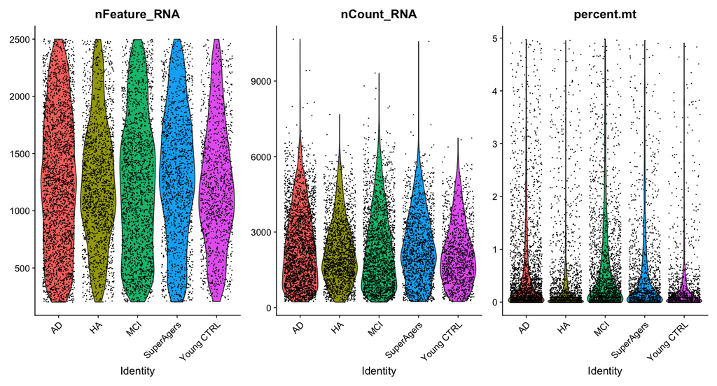

[figure not shown]

# Normalizing the data

```r
pbmc <- NormalizeData(pbmc, normalization.method = "LogNormalize", scale.factor = 1e4)
```

For clarity, in this previous line of code (and in future commands), we provide the default values for certain parameters in the function call. However, this isn’t required and the same behavior can be achieved with:

```r
pbmc <- NormalizeData(pbmc)
```

# Identification of highly variable features (feature selection)

We next calculate a subset of features that exhibit high cell-to-cell variation in the dataset (i.e, they are highly expressed in some cells, and lowly expressed in others). We and [others](https://www.nature.com/articles/nmeth.2645) have found that focusing on these genes in downstream analysis helps to highlight biological signal in single-cell datasets.

Our procedure in Seurat is described in detail [here](https://doi.org/10.1016/j.cell.2019.05.031), and improves on previous versions by directly modeling the mean-variance relationship inherent in single-cell data, and is implemented in the `FindVariableFeatures()` function. By default, we return 2,000 features per dataset. These will be used in downstream analysis, like PCA.

```r
pbmc <- FindVariableFeatures(pbmc, selection.method = 'vst', nfeatures = 2000)

# Identify the 10 most highly variable genes
top10 <- head(VariableFeatures(pbmc), 10)

# plot variable features with and without labels
plot1 <- VariableFeaturePlot(pbmc)
plot2 <- LabelPoints(plot = plot1, points = top10, repel = TRUE)
plot1 + plot2
```

[output not shown]

# Scaling the data

Next, we apply a linear transformation (‘scaling’) that is a standard pre-processing step prior to dimensional reduction techniques like PCA. The `ScaleData()` function:

- Shifts the expression of each gene, so that the mean expression across cells is 0
- Scales the expression of each gene, so that the variance across cells is 1
  - This step gives equal weight in downstream analyses, so that highly-expressed genes do not dominate
- The results of this are stored in `pbmc[["RNA"]]@scale.data`

```r
pbmc <- ScaleData(pbmc)
```

**How can I remove unwanted sources of variation, as in Seurat v2?**

In `Seurat v2` we also use the `ScaleData()` function to remove unwanted sources of variation from a single-cell dataset. For example, we could ‘regress out’ heterogeneity associated with (for example) cell cycle stage, or mitochondrial contamination. These features are still supported in `ScaleData()` in `Seurat v3`, i.e.:

```r
pbmc <- ScaleData(pbmc, vars.to.regress = 'percent.mt')
```

However, particularly for advanced users who would like to use this functionality, we strongly recommend the use of our new normalization workflow, `SCTransform()`. The method is described in our [paper](https://genomebiology.biomedcentral.com/articles/10.1186/s13059-019-1874-1), with a separate vignette using Seurat v3 here. As with `ScaleData()`, the function `SCTransform()` also includes a `vars.to.regress` parameter.

# Perform linear dimensional reduction

Next we perform PCA on the scaled data. By default, only the previously determined variable features are used as input, but can be defined using `features` argument if you wish to choose a different subset.

Seurat provides several useful ways of visualizing both cells and features that define the PCA, including `VizDimReduction()`, `DimPlot()`, and `DimHeatmap()`

```r
# Examine and visualize PCA results a few different ways
print(pbmc[['pca']], dims = 1:5, nfeatures = 5)
VizDimLoadings(pbmc, dims = 1:2, reduction = 'pca')
DimPlot(pbmc, reduction = 'pca')
```

[output not shown]

In particular `DimHeatmap()` allows for easy exploration of the primary sources of heterogeneity in a dataset, and can be useful when trying to decide which PCs to include for further downstream analyses. Both cells and features are ordered according to their PCA scores. Setting `cells` to a number plots the ‘extreme’ cells on both ends of the spectrum, which dramatically speeds plotting for large datasets. Though clearly a supervised analysis, we find this to be a valuable tool for exploring correlated feature sets.

```r
DimHeatmap(pbmc, dims = 1, cells = 500, balanced = TRUE)
```

[output not shown]

```r
DimHeatmap(pbmc, dims = 1:15, cells = 500, balanced = TRUE)
```

[output not shown]

# Determine the ‘dimensionality’ of the dataset

To overcome the extensive technical noise in any single feature for scRNA-seq data, Seurat clusters cells based on their PCA scores, with each PC essentially representing a ‘metafeature’ that combines information across a correlated feature set. The top principal components therefore represent a robust compression of the dataset. However, how many components should we choose to include? 10? 20? 100?

In Macosko *et al*, we implemented a resampling test inspired by the JackStraw procedure. We randomly permute a subset of the data (1% by default) and rerun PCA, constructing a ‘null distribution’ of feature scores, and repeat this procedure. We identify ‘significant’ PCs as those who have a strong enrichment of low p-value features.

```r
# NOTE: This process can take a long time for big datasets, comment out for expediency. More approximate techniques such as those implemented in ElbowPlot() can be used to reduce computation time
pbmc <- JackStraw(pbmc, num.replicate = 100)
pbmc <- ScoreJackStraw(pbmc, dims = 1:20)
```

```r
JackStrawPlot(pbmc, dims = 1:15)
```

[output not shown]

```r
ElbowPlot(pbmc)
```

[output not shown]

# Cluster the cells

Seurat v3 applies a graph-based clustering approach, building upon initial strategies in (Macosko *et al*). Importantly, the *distance metric* which drives the clustering analysis (based on previously identified PCs) remains the same. However, our approach to partitioning the cellular distance matrix into clusters has dramatically improved. Our approach was heavily inspired by recent manuscripts which applied graph-based clustering approaches to scRNA-seq data [[SNN-Cliq, Xu and Su, Bioinformatics, 2015]](http://bioinformatics.oxfordjournals.org/content/early/2015/02/10/bioinformatics.btv088.abstract) and CyTOF data [[PhenoGraph, Levine *et al*., Cell, 2015]](http://www.ncbi.nlm.nih.gov/pubmed/26095251). Briefly, these methods embed cells in a graph structure - for example a K-nearest neighbor (KNN) graph, with edges drawn between cells with similar feature expression patterns, and then attempt to partition this graph into highly interconnected ‘quasi-cliques’ or ‘communities’.

As in PhenoGraph, we first construct a KNN graph based on the euclidean distance in PCA space, and refine the edge weights between any two cells based on the shared overlap in their local neighborhoods (Jaccard similarity). This step is performed using the `FindNeighbors()` function, and takes as input the previously defined dimensionality of the dataset (first 10 PCs).

To cluster the cells, we next apply modularity optimization techniques such as the Louvain algorithm (default) or SLM [[SLM, Blondel *et al*., Journal of Statistical Mechanics]](http://dx.doi.org/10.1088/1742-5468/2008/10/P10008), to iteratively group cells together, with the goal of optimizing the standard modularity function. The `FindClusters()` function implements this procedure, and contains a resolution parameter that sets the ‘granularity’ of the downstream clustering, with increased values leading to a greater number of clusters. We find that setting this parameter between 0.4-1.2 typically returns good results for single-cell datasets of around 3K cells. Optimal resolution often increases for larger datasets. The clusters can be found using the `Idents()` function.

```r
pbmc <- FindNeighbors(pbmc, dims = 1:10)
pbmc <- FindClusters(pbmc, resolution = 0.5)

# Look at cluster IDs of the first 5 cells
head(Idents(pbmc), 5)
```

[output not shown]

# Run non-linear dimensional reduction (UMAP/tSNE)

Seurat offers several non-linear dimensional reduction techniques, such as tSNE and UMAP, to visualize and explore these datasets. The goal of these algorithms is to learn the underlying manifold of the data in order to place similar cells together in low-dimensional space. Cells within the graph-based clusters determined above should co-localize on these dimension reduction plots. As input to the UMAP and tSNE, we suggest using the same PCs as input to the clustering analysis.

```r
# If you haven't installed UMAP, you can do so via reticulate::py_install(packages = "umap-learn")
pbmc <- RunUMAP(pbmc, dims = 1:10)
```

```r
# note that you can set `label = TRUE` or use the LabelClusters function to help label individual clusters
DimPlot(pbmc, reduction = 'umap')
```

[output not shown]

You can save the object at this point so that it can easily be loaded back in without having to rerun the computationally intensive steps performed above, or easily shared with collaborators.

```r
saveRDS(pbmc, file = "../output/pbmc_tutorial.rds")
```

# Finding differentially expressed features (cluster biomarkers)

Seurat can help you find markers that define clusters via differential expression. By default, it identifies positive and negative markers of a single cluster (specified in `ident.1`), compared to all other cells. `FindAllMarkers()` automates this process for all clusters, but you can also test groups of clusters vs. each other, or against all cells.

The `min.pct` argument requires a feature to be detected at a minimum percentage in either of the two groups of cells, and the thresh.test argument requires a feature to be differentially expressed (on average) by some amount between the two groups. You can set both of these to 0, but with a dramatic increase in time - since this will test a large number of features that are unlikely to be highly discriminatory. As another option to speed up these computations, `max.cells.per.ident` can be set. This will downsample each identity class to have no more cells than whatever this is set to. While there is generally going to be a loss in power, the speed increases can be significant and the most highly differentially expressed features will likely still rise to the top.

```r
# find all markers of cluster 2
cluster2.markers <- FindMarkers(pbmc, ident.1 = 2, min.pct = 0.25)
head(cluster2.markers, n = 5)
# find all markers distinguishing cluster 5 from clusters 0 and 3
cluster5.markers <- FindMarkers(pbmc, ident.1 = 5, ident.2 = c(0, 3), min.pct = 0.25)
head(cluster5.markers, n = 5)
# find markers for every cluster compared to all remaining cells, report only the positive ones
pbmc.markers <- FindAllMarkers(pbmc, only.pos = TRUE, min.pct = 0.25, logfc.threshold = 0.25)
pbmc.markers %>% group_by(cluster) %>% slice_max(n = 2, order_by = avg_log2FC)
```

[output not shown]

Seurat has several tests for differential expression which can be set with the test.use parameter (see our DE vignette for details). For example, the ROC test returns the ‘classification power’ for any individual marker (ranging from 0 - random, to 1 - perfect).

```r
cluster0.markers <- FindMarkers(pbmc, ident.1 = 0, logfc.threshold = 0.25, test.use = "roc", only.pos = TRUE)
```

We include several tools for visualizing marker expression. `VlnPlot()` (shows expression probability distributions across clusters), and `FeaturePlot()` (visualizes feature expression on a tSNE or PCA plot) are our most commonly used visualizations. We also suggest exploring `RidgePlot()`, `CellScatter()`, and `DotPlot()` as additional methods to view your dataset.

```r
VlnPlot(pbmc, features = c("MS4A1", "CD79A"))
# you can plot raw counts as well
VlnPlot(pbmc, features = c("NKG7", "PF4"), slot = 'counts', log = TRUE)
FeaturePlot(pbmc, features = c("MS4A1", "GNLY", "CD3E", "CD14", "FCER1A", "FCGR3A", "LYZ", "PPBP", "CD8A"))
```

[output not shown]

```r
pbmc.markers %>% group_by(cluster) %>% top_n(n = 10, wt = avg_log2FC) -> top10
DoHeatmap(pbmc, features = top10$gene) + NoLegend()
```

[output not shown]

```r
new.cluster.ids <- c("Naive CD4 T", "CD14+ Mono", "Memory CD4 T", "B", "CD8 T", "FCGR3A+ Mono", "NK", "DC", "Platelet")
names(new.cluster.ids) <- levels(pbmc)
pbmc <- RenameIdents(pbmc, new.cluster.ids)
DimPlot(pbmc, reduction = 'umap', label = TRUE, pt.size = 0.5) + NoLegend()
```

[output not shown]

```r
saveRDS(pbmc, file = "../output/pbmc3k_final.rds")
```